# shehla

Project Python Foundations: FoodHub Data Analysis

**Marks: 60**

Context

The number of restaurants in New York is increasing day by day. Lots of students and busy professionals rely on those restaurants due to their hectic lifestyles. Online food delivery service is a great option for them. It provides them with good food from their favorite restaurants. A food aggregator company FoodHub offers access to multiple restaurants through a single smartphone app.

The app allows the restaurants to receive a direct online order from a customer. The app assigns a delivery person from the company to pick up the order after it is confirmed by the restaurant. The delivery person then uses the map to reach the restaurant and waits for the food package. Once the food package is handed over to the delivery person, he/she confirms the pick-up in the app and travels to the customer's location to deliver the food. The delivery person confirms the drop-off in the app after delivering the food package to the customer. The customer can rate the order in the app. The food aggregator earns money by collecting a fixed margin of the delivery order from the restaurants.

Objective

The food aggregator company has stored the data of the different orders made by the registered customers in their online portal. They want to analyze the data to get a fair idea about the demand of different restaurants which will help them in enhancing their customer experience. Suppose you are hired as a Data Scientist in this company and the Data Science team has shared some of the key questions that need to be answered. Perform the data analysis to find answers to these questions that will help the company to improve the business.

Data Description

The data contains the different data related to a food order. The detailed data dictionary is given below.

Data Dictionary

- order_id: Unique ID of the order
- customer_id: ID of the customer who ordered the food
- restaurant_name: Name of the restaurant
- cuisine_type: Cuisine ordered by the customer
- cost: Cost of the order
- day_of_the_week: Indicates whether the order is placed on a weekday or weekend (The weekday is from Monday to Friday and the weekend is Saturday and Sunday)
- rating: Rating given by the customer out of 5
- food_preparation_time: Time (in minutes) taken by the restaurant to prepare the food. This is calculated by taking the difference between the timestamps of the restaurant's order confirmation and the delivery person's pick-up confirmation.
- delivery_time: Time (in minutes) taken by the delivery person to deliver the food package. This is calculated by taking the difference between the timestamps of the delivery person's pick-up confirmation and drop-off information

Let us start by importing the required libraries

```python
# import libraries for data manipulation
import numpy as np
import pandas as pd

# import libraries for data visualization
import matplotlib.pyplot as plt
import seaborn as sns
```

Understanding the structure of the data

```python
# uncomment and run the following lines for Google Colab
# from google.colab import drive
# drive.mount('/content/drive')
```

```python
# read the data
df = pd.read_csv('foodhub_order.csv')
# returns the first 5 rows
df.head()
```

|  | order_id | customer_id | restaurant_name | cuisine_type | cost_of_the_order | day_of_the_week | rating | food_preparation_time | delivery_time |
| --- | --- | --- | --- | --- | --- | --- | --- | --- | --- |
| 0 | 1477147 | 337525 | Hangawi | Korean | 30.75 | Weekend | Not given | 25 | 20 |
| 1 | 1477685 | 358141 | Blue Ribbon Sushi Izakaya | Japanese | 12.08 | Weekend | Not given | 25 | 23 |
| 2 | 1477070 | 66393 | Cafe Habana | Mexican | 12.23 | Weekday | 5 | 23 | 28 |
| 3 | 1477334 | 106968 | Blue Ribbon Fried Chicken | American | 29.20 | Weekend | 3 | 25 | 15 |
| 4 | 1478249 | 76942 | Dirty Bird to Go | American | 11.59 | Weekday | 4 | 25 | 24 |

# Observations:

The DataFrame has 9 columns as mentioned in the Data Dictionary. Data in each row corresponds to the order placed by a customer.

Question 1:** How many rows and columns are present in the data? [0.5 mark]

```python
df.shape
```

```
(1898, 9)
```

There are 1898 rows and 9 columns present in the data.

Question 2:** What are the datatypes of the different columns in the dataset? (The info() function can be used) [0.5 mark]

```python
# Use info() to print a concise summary of the DataFrame
df.info()
```

```
<class 'pandas.core.frame.DataFrame'>
RangeIndex: 1898 entries, 0 to 1897
Data columns (total 9 columns):
 #   Column                 Non-Null Count  Dtype
---  ------                 --------------  -----
 0   order_id               1898 non-null   int64
 1   customer_id            1898 non-null   int64
 2   restaurant_name        1898 non-null   object
 3   cuisine_type           1898 non-null   object
 4   cost_of_the_order      1898 non-null   float64
 5   day_of_the_week        1898 non-null   object
 6   rating                 1898 non-null   object
 7   food_preparation_time  1898 non-null   int64
 8   delivery_time          1898 non-null   int64
dtypes: float64(1), int64(4), object(4)
memory usage: 133.6+ KB
```

#### Observations:

There are 5 numerical columns in the data and 4 object type columns.

### **Question 3:** Are there any missing values in the data? If yes, treat them using an appropriate method. [1 mark]

```python
# Write your code here
df.replace("Not given", np.nan, inplace=True)
df.isnull().sum()
# df['rating'] = df['rating'].fillna(value= df['rating'].median())
# df.isnull().sum()
# df.head()
```

```
order_id                   0
customer_id                0
restaurant_name            0
cuisine_type               0
cost_of_the_order          0
day_of_the_week            0
rating                   736
food_preparation_time      0
delivery_time              0
dtype: int64
```

#### Observations:

There are 736 missing values in the data column.

Question 4:** Check the statistical summary of the data. What is the minimum, average, and maximum time it takes for food to be prepared once an order is placed? [2 marks]

```python
df.describe(include='all').T
```

|  | count | unique | top | freq | mean | std | min | 25% | 50% | 75% | max |
| --- | --- | --- | --- | --- | --- | --- | --- | --- | --- | --- | --- |
| order_id | 1898.0 | NaN | NaN | NaN | 1477495.5 | 548.049724 | 1476547.0 | 1477021.25 | 1477495.5 | 1477969.75 | 1478444.0 |
| customer_id | 1898.0 | NaN | NaN | NaN | 171168.478398 | 113698.139743 | 1311.0 | 77787.75 | 128600.0 | 270525.0 | 405334.0 |
| restaurant_name | 1898 | 178 | Shake Shack | 219 | NaN | NaN | NaN | NaN | NaN | NaN | NaN |
| cuisine_type | 1898 | 14 | American | 584 | NaN | NaN | NaN | NaN | NaN | NaN | NaN |
| cost_of_the_order | 1898.0 | NaN | NaN | NaN | 16.498851 | 7.483812 | 4.47 | 12.08 | 14.14 | 22.2975 | 35.41 |
| day_of_the_week | 1898 | 2 | Weekend | 1351 | NaN | NaN | NaN | NaN | NaN | NaN | NaN |
| rating | 1162 | 3 | 5 | 588 | NaN | NaN | NaN | NaN | NaN | NaN | NaN |
| food_preparation_time | 1898.0 | NaN | NaN | NaN | 27.37197 | 4.632481 | 20.0 | 23.0 | 27.0 | 31.0 | 35.0 |
| delivery_time | 1898.0 | NaN | NaN | NaN | 24.161749 | 4.972637 | 15.0 | 20.0 | 25.0 | 28.0 | 33.0 |

#### Observations:

The minimum time for the food to be prepared once the order is placed is 20 minutes. The average time for the food to be prepared is 27.37 minutes. The maximum time for the food to be prepared is 35 minutes.

Question 5:** How many orders are not rated? [1 mark]

```python
df['rating'].replace(['Not given'],np.nan)
```

```
0       NaN
1       NaN
2         5
3         3
4         4
       ...
1893      5
1894      5
1895    NaN
1896      5
1897    NaN
Name: rating, Length: 1898, dtype: object
```

```python
df['rating'].value_counts()
```

```
5    588
4    386
3    188
Name: rating, dtype: int64
```

#### Observations:

736 orders were not rated.

### Exploratory Data Analysis (EDA)

Univariate Analysis:

Let's check the distribution of numerical columns:

Understanding the distribution of cost_of_the_order

### **Question 6:** Explore all the variables and provide observations on their distributions. (Generally, histograms, boxplots, countplots, etc. are used for univariate exploration.) [9 marks]

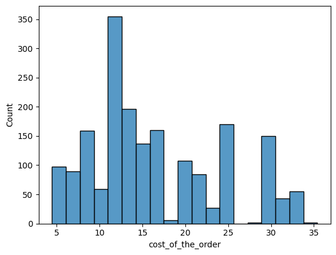

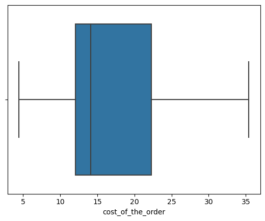

```python
sns.histplot(data=df, x='cost_of_the_order')
plt.show()
sns.boxplot(data=df, x='cost_of_the_order')
plt.show()
```

The cost_of the order is slightly right-skewed. Almost half of the customers pay less than 14 dollars. 50%of the cost of the orders lie between 12 to 23 dollars.

Understanding the distribution of the food_preparation_time:

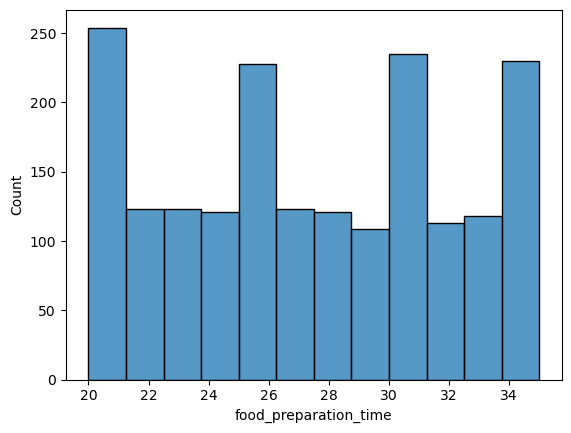

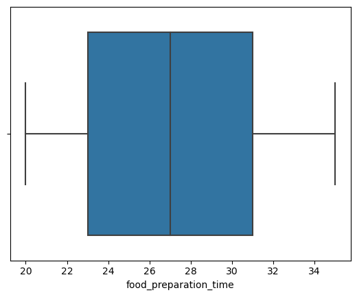

```python
sns.histplot(data=df, x='food_preparation_time')
plt.show()
sns.boxplot(data=df, x='food_preparation_time')
plt.show()
```

It is multimodal distribution. The data is uniformly distributed. There are no outliers. 50%of the data lie between approximately between 23 minutes and 31 minutes.

Let's check the distribution of the delivery_time

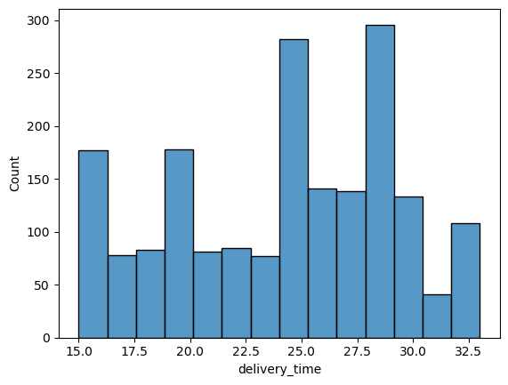

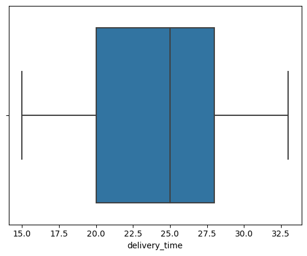

```python
sns.histplot(data=df, x='delivery_time')
plt.show()

sns.boxplot(data=df, x='delivery_time')
plt.show()
```

The distribution of delivery time is slightly left skewed. 50%of the data lies between approximately between 20 to 28 mins.

We have seen the distribution of the numerical columns.Now let's move on to the categorical column and use the countplot to see their distribution.

Understanding the distribution of Cusine type:

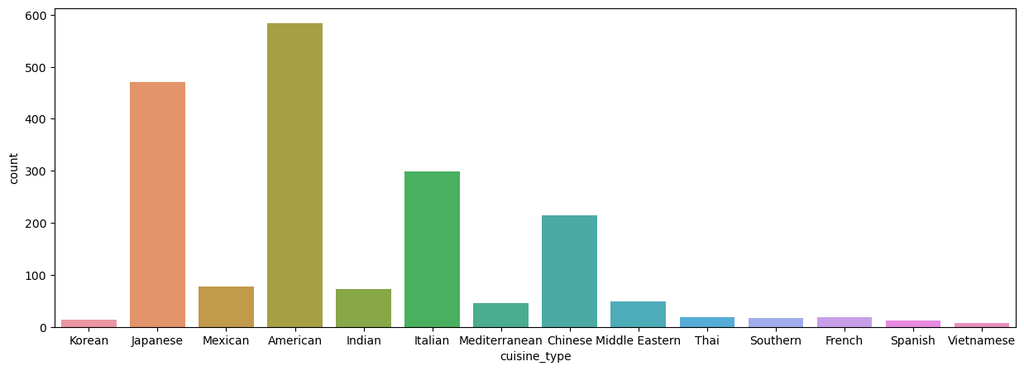

```python
plt.figure(figsize = (15,5))
sns.countplot(data = df, x = 'cuisine_type')
```

The top cuisine type in terms of order received is American followed by Japnese and Italian. The no.of order received for the American Cuisine is almost 580. Vietnamese has the lowest no. of orders received around 10.

```python
Understanding the distribution of the day of the week:
```

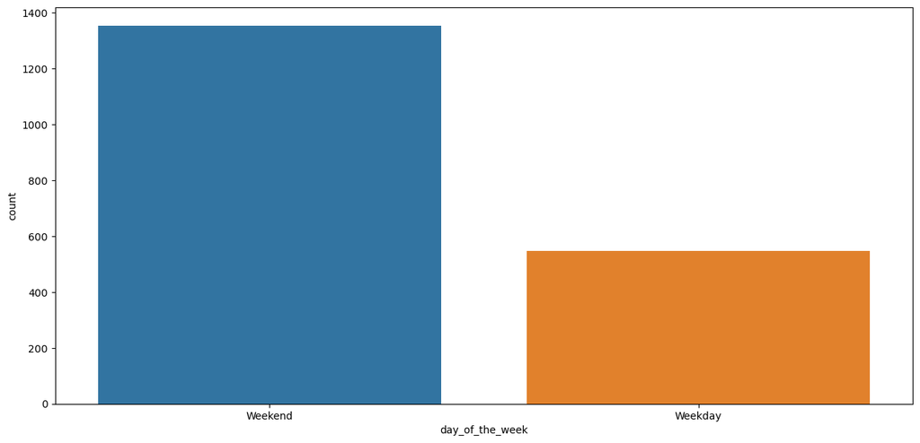

```python
plt.figure(figsize=(15,7))
sns.countplot(data=df, x='day_of_the_week')
```

```python
More orders were placed on weekend than weekdays.
```

### **Question 7**: Which are the top 5 restaurants in terms of the number of orders received? [1 mark]

```python
df['restaurant_name'].unique()
```

```
array(['Hangawi', 'Blue Ribbon Sushi Izakaya', 'Cafe Habana',
       'Blue Ribbon Fried Chicken', 'Dirty Bird to Go',
       'Tamarind TriBeCa', 'The Meatball Shop', 'Barbounia',
       'Anjappar Chettinad', 'Bukhara Grill',
       'Big Wong Restaurant \x8c_¤¾Ñ¼', 'Empanada Mama (closed)', 'Pylos',
       "Lucky's Famous Burgers", 'Shake Shack', 'Sushi of Gari',
       'RedFarm Hudson', 'Blue Ribbon Sushi',
       'Five Guys Burgers and Fries', 'Tortaria', 'Cafe Mogador',
       'Otto Enoteca Pizzeria', 'Vezzo Thin Crust Pizza',
       'Sushi of Gari 46', 'The Kati Roll Company', 'Klong',
       '5 Napkin Burger', 'TAO', 'Parm', 'Sushi Samba',
       'Haru Gramercy Park', 'Chipotle Mexican Grill $1.99 Delivery',
       'RedFarm Broadway', 'Cafeteria', 'DuMont Burger',
       "Sarabeth's East", 'Hill Country Fried Chicken', 'Bistango',
       "Jack's Wife Freda", "Mamoun's Falafel", 'Prosperity Dumpling',
       'Blue Ribbon Sushi Bar & Grill', 'Westville Hudson',
       'Blue Ribbon Brooklyn', 'Nobu Next Door', 'Osteria Morini',
       'Haandi', 'Benihana', 'Han Dynasty', 'Chote Nawab',
       'Mission Cantina', "Xi'an Famous Foods", 'Rubirosa',
       "Joe's Shanghai \x8e_À\x8eü£¾÷´", 'Bareburger', 'The Odeon',
       'Pongsri Thai', 'Yama Japanese Restaurant', 'Momoya',
       'Balthazar Boulangerie', 'CafÌ© China', 'Boqueria',
       'Song Thai Restaurant & Bar', 'Five Leaves',
       'Pinto Nouveau Thai Bistro', "Amy Ruth's", 'Pepe Giallo',
       'indikitch', 'Yama 49', 'Piccolo Angolo', 'Pepe Rosso To Go',
       "L'Express", 'Amma', 'Delicatessen', "S'MAC",
       "Vanessa's Dumplings", 'Bhatti Indian Grill', 'Taro Sushi',
       'Donburi-ya', 'Hatsuhana', 'Samurai Mama', 'Waverly Diner',
       'Tarallucci e Vino Restaurant', "P.J. Clarke's",
       'Lantern Thai Kitchen', 'ilili Restaurant', 'The Smile',
       "Vanessa's Dumpling House", "Bubby's ", 'Woorijip',
       'Dirty Bird To Go (archived)', 'Haveli Indian Restaurant',
       'Dos Caminos', 'da Umberto', 'Sushi of Gari Tribeca',
       'Burger Joint', 'Room Service', "Sarabeth's Restaurant",
       'Xe May Sandwich Shop', 'Hibino', 'Mira Sushi', 'Melt Shop',
       'J. G. Melon', 'Hummus Place', 'Saravanaa Bhavan',
       'Friend of a Farmer', 'The Loop', 'Balade', 'Posto',
       'Terakawa Ramen', 'Kambi Ramen House', 'Wo Hop Restaurant',
       'Spice Thai', "Dickson's Farmstand Meats",
       'UVA Wine Bar & Restaurant', 'Serafina Fabulous Pizza',
       'Gaia Italian Cafe', 'Chola Eclectic Indian Cuisine',
       'Hot Kitchen', 'Junoon', 'Ravagh Persian Grill', 'Rohm Thai',
       'Dig Inn Seasonal Market', 'Olea', 'Cho Dang Gol',
       'El Parador Cafe', 'Socarrat Paella Bar',
       "Don's Bogam BBQ & Wine Bar", 'Alidoro', "Tony's Di Napoli",
       'Cipriani Le Specialita', 'Sushi Choshi', 'Kanoyama', 'V-Nam Cafe',
       'Zero Otto Nove', 'Dos Caminos Soho', 'Go! Go! Curry!',
       'La Follia', 'Izakaya Ten', '12 Chairs', 'Philippe Chow',
       'The MasalaWala', 'brgr', "Carmine's", 'Asuka Sushi', 'Aurora',
       "Sarabeth's", 'Crema Restaurante', "Big Daddy's",
       'Moonstruck on Second', 'Cafe de La Esquina', 'Olive Garden',
       '67 Burger', 'Tres Carnes', "Schnipper's Quality Kitchen",
       'Nha Trang One', 'Market Table', 'Galli Restaurant',
       'Hampton Chutney Co.', 'Byblos Restaurant',
       'Grand Sichuan International', 'Le Grainne Cafe', 'Il Bambino',
       'Kori Restaurant and Bar', 'DespaÌ±a', 'Lamarca Pasta',
       'Lucky Strike', "Paul & Jimmy's", 'Hunan Manor', "Coppola's East",
       'Emporio', 'Wa Jeal', 'Le Zie 2000 Trattoria', 'Rye House',
       "Hiroko's Place", 'Frank Restaurant', "Sarabeth's West",
       "'wichcraft"], dtype=object)
```

```python
df['restaurant_name'].value_counts()
```

```
Shake Shack                  219
The Meatball Shop            132
Blue Ribbon Sushi            119
Blue Ribbon Fried Chicken     96
Parm                          68
                            ...
Sushi Choshi                   1
Dos Caminos Soho               1
La Follia                      1
Philippe Chow                  1
'wichcraft                     1
Name: restaurant_name, Length: 178, dtype: int64
```

The top 5 restaurants in terms of the orders received are:

Shake Shack The Meatball Shop Blue Ribbon Sushi Blue Ribbon Fried Chicken Parm

### **Question 8**: Which is the most popular cuisine on weekends? [1 mark]

```python
df_weekend=df[df['day_of_the_week']=='Weekend']
df_weekend['cuisine_type'].value_counts()
```

```
American          415
Japanese          335
Italian           207
Chinese           163
Mexican            53
Indian             49
Mediterranean      32
Middle Eastern     32
Thai               15
French             13
Korean             11
Southern           11
Spanish            11
Vietnamese          4
Name: cuisine_type, dtype: int64
```

#### Observations:

American cuisine appears to be most popular on weekends.

### **Question 9**: What percentage of the orders cost more than 20 dollars? [2 marks]

```python
df_greater_than_20=df[df['cost_of_the_order']>20]

print('The number of total orders that cost above 20 dollarsi is:',df_greater_than_20)
percentage = (df_greater_than_20.shape[0]) / df.shape[0] * 100
print("Percentage of orders above 20 dollars:", round(percentage, 2), '%')
```

[output not shown]

[output cut: 26 more lines]

#### Observations:

The percentage of orders cost more than 20 dollars is 29.24%

### **Question 10**: What is the mean order delivery time? [1 mark]

```python
mean_del_time = df['delivery_time'].mean()

print('The mean delivery time for this dataset is',round(mean_del_time, 2), 'minutes' )
```

```
The mean delivery time for this dataset is 24.16 minutes
```

**Question 11:** The company has decided to give 20% discount vouchers to the top 3 most frequent customers. Find the IDs of these customers and the number of orders they placed. [1 mark]

```python
df['customer_id'].value_counts()
```

```
52832     13
47440     10
83287      9
250494     8
259341     7
          ..
385426     1
254913     1
289597     1
74412      1
397537     1
Name: customer_id, Length: 1200, dtype: int64
```

### Observations:

The customer with id 52832 placed 13 orders. The customer with id 47440 placed 10 orders. The customer with id 83287 placed 9 orders.

Multivariate Analysis

### **Question 12**: Perform a multivariate analysis to explore relationships between the important variables in the dataset. (It is a good idea to explore relations between numerical variables as well as relations between numerical and categorical variables) [10 marks]

Cusine vs Cost of the order:

Let's find the relationship between the cost of the order and cuisine type

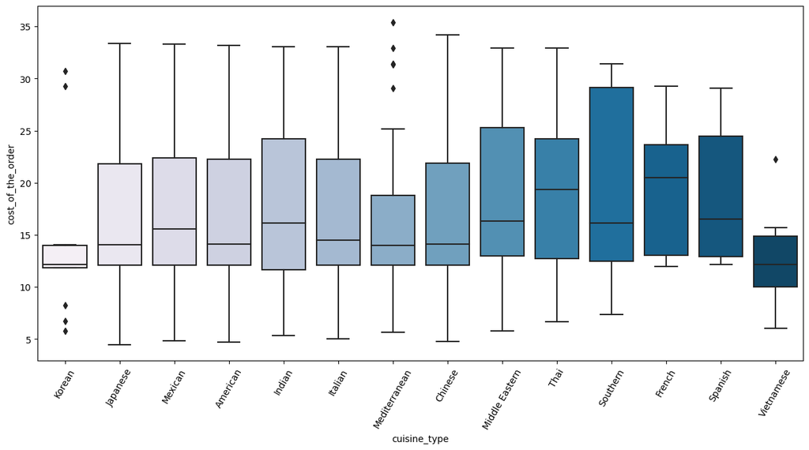

```python
plt.figure(figsize=(15,7))
sns.boxplot(x= "cuisine_type", y= "cost_of_the_order",  data = df, palette = 'PuBu')
plt.xticks(rotation=60)
plt.show()
```

Relationship between the food preparation type and cuisine type;

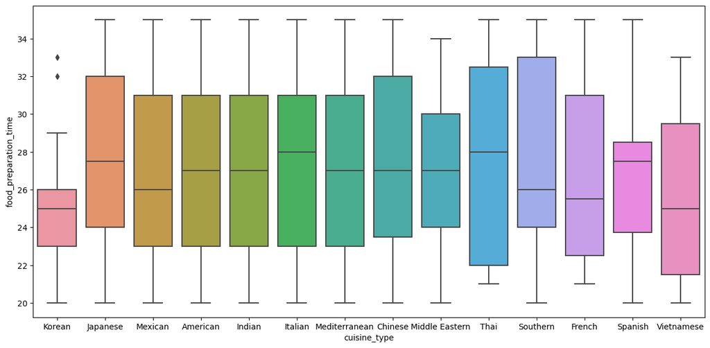

```python
plt.figure(figsize=(15,7))
sns.boxplot(x = "cuisine_type",y ="food_preparation_time", data = df)
plt.show()
```

Relationship between the day of the week and delivery time:

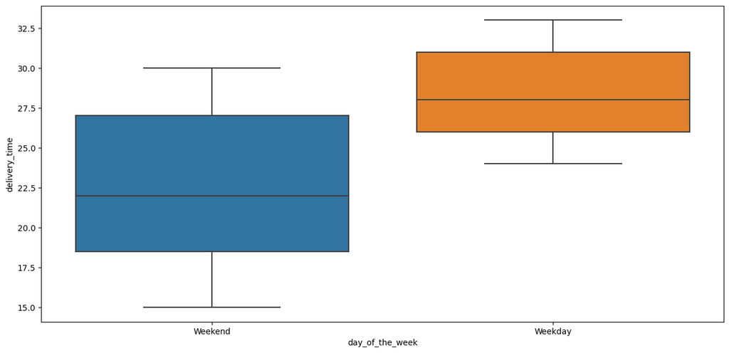

```python
plt.figure(figsize=(15,7))
sns.boxplot(x = "day_of_the_week", y = "delivery_time", data = df)
plt.show()
```

The delivery time for weekdays is more than on weekends. The maximum delivery time for weekend is 30 minutes whereas for weekday it is around 33 minutes.